# Personal Regression Application

## Instructions

1. Use regression to help you find meaningful insights about your own life.
   - You could study your spending and earning habits.
   - You could consider your health habits as recorded by your phone or other electronic gadget.
   - You could consider the impacts of social media usage measured by number of posts, time spent, or words written, compared to your success in school each semester.
   - You could weigh your future job opportunities, graduate school, or other options against each other to find a “best choice” for you.
   - You could even take a second attempt at the Project 3 analysis, and follow up with more detail that better reflects your actual vehicle scenario. This would have to differ rather significantly from Project 3 though.
2. Your work should show breadth and depth of knowledge in the things we have learned this semester.

## Grading

1. Breadth of Knowledge {10} Points
   - What percentage of regression concepts from this semester does your analysis demonstrate?
2. Depth of Knowledge {10} Points
   - Does your analysis show great expertise in at least a few of the regression topics we have covered this semester? Specifically, you need to demonstrate good ability with: the mathematical model statement, hypothesis testing, confidence or prediction intervals, and transformations.

## Background

I wanted to take a look at how much electricity I use and I how much I spend relative the the temperature outside. This will help my wife and I make decesions regarding our budget and perhaps we can forecast just how much money to set aside every month. I looked at my electricty usage over the past few years to develop a simple linear model.

## Data

Let’s read in my data from Rocky Mountain Power Company:

```r
bill <- read_csv(here::here("project_04/bill.csv")) %>%
  rename(temp = `Average Temperature`, bill = `Bill Amount`)
```

The data came really clean so there will be little cleaning to do. Let’s make a quick visualization of the temperature vs cost:

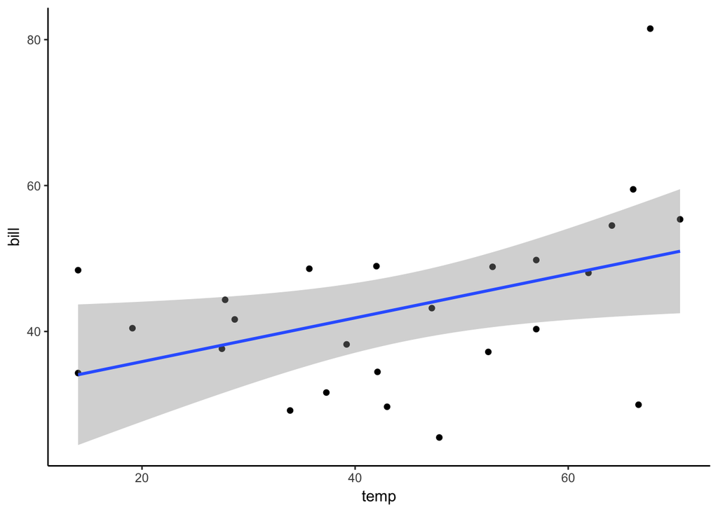

```r
bill %>%
  ggplot(aes(x = temp, y = bill)) +
  geom_point() +
  geom_smooth(method = "lm") +
  theme_classic()
```

As we can see there are a few outliers in these data. Let’s run a model and check our assumptions.

```r
bill.lm <- lm(bill ~ temp, data = bill)

summary(bill.lm) %>%
  pander::pander()
```

|  | Estimate | Std. Error | t value | Pr(>\|t\|) |
| --- | --- | --- | --- | --- |
| **(Intercept)** | 29.88 | 6.364 | 4.694 | 9.971e-05 |
| **temp** | 0.2997 | 0.1336 | 2.243 | 0.03485 |

Fitting linear model: bill ~ temp

| Observations | Residual Std. Error | $R^2$ | Adjusted $R^2$ |
| --- | --- | --- | --- |
| 25 | 11.12 | 0.1794 | 0.1438 |

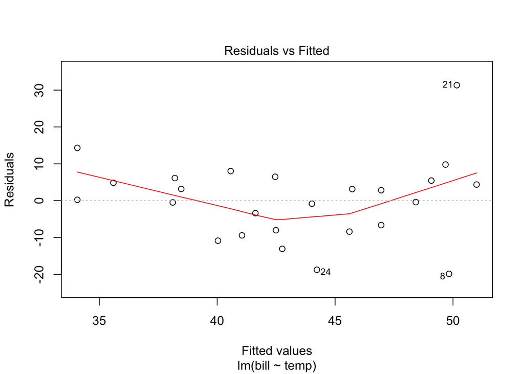

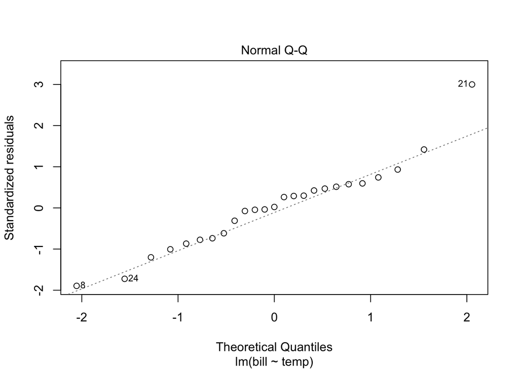

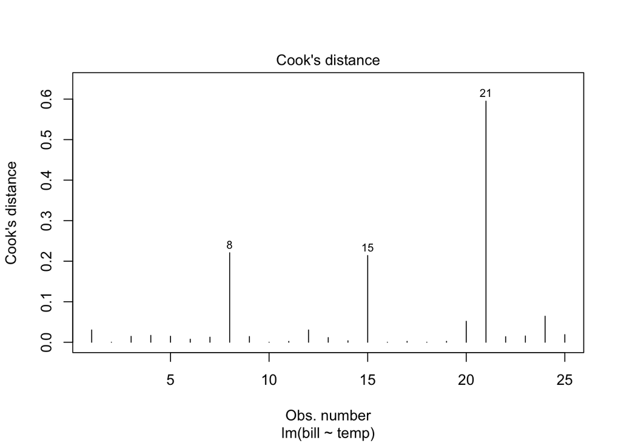

```r
plot(bill.lm, which = c(1:2,4))
```

As we can see the assumptions are broken but not terribly so. Let’s try a robust regression to smooth things out a bit.

```r
bill.rlm <- MASS::rlm(bill ~ temp, data = bill)

summary(bill.rlm)
```

```
##
## Call: rlm(formula = bill ~ temp, data = bill)
## Residuals:
##      Min       1Q   Median       3Q      Max
## -18.4781  -7.6642   0.7832   5.9434  32.7931
##
## Coefficients:
##             Value   Std. Error t value
## (Intercept) 31.5574  5.5736     5.6620
## temp         0.2535  0.1170     2.1661
##
## Residual standard error: 9.955 on 23 degrees of freedom
```

I guess we need to lay off the air-conditioning in the summer.

*Sorry for the lackluster project, my original idea kind of fell apart last minute as the data I was gathering was uncleanable*